# Introduction to Jupyter Notebooks (and Google Colab) for Data Analytics

### Suzanne Little

## Outline

- What is a notebook?
- Jupyter, iPython, Colab ??
- Why are notebooks useful for Data Analytics?
- Some tips and tricks

## What is a notebook?

> "**Computational Notebook documents**: A shareable document that combines computer code, plain language descriptions, data, rich visualizations like 3D models, charts, mathematics, graphs and figures, and interactive controls." ([source](https://jupyter-notebook.readthedocs.io/en/stable/notebook.html))

A document (stored in JSON format) that captures the inputs and outputs of a interactive session as well as additional text that accompanies the code as a complete computational and documented record.

Notebooks are made up of *cells*. The cell can be a *markdown* or *code* cell.

- **Code**: A code cell allows you to edit, write new code and execute the code, with full syntax highlighting and tab completion. The default kernel to run the code is python but others are available.
- **Markdown**: Document the code with rich text using [markdown](https://jupyter-notebook.readthedocs.io/en/stable/examples/Notebook/Working%20With%20Markdown%20Cells.html) to format style, add links or embed images.

[figure not shown]

[figure not shown]

## Jupyter, iPython, Colab?

- Jupyter: Package that allows you to edit, manage and run notebooks. Simplest option to install is to use [Anaconda](https://www.anaconda.com/). Installs python and many critical libraries for data analytics plus jupyter. Notebooks run locally.
- IPython: Original project, still see this in the file name .ipynb
- Colab: Google Colab runs notebooks that are mostly equivalent but are stored and executed in the cloud rather than locally

## Why are notebooks useful for Data Analytics?

Recall the pipeline from week 1:

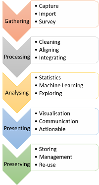

Eight reasons to use notebooks:

1. Fully document your work (markdown in Text cells)
2. Easily display embedded graphs
3. Embed mathematical functions
4. Use Google Colab means that your work is online, sharable and backed up
5. Use git to store and share your notebooks and they will be rendered for display
6. Use widgets to create interactive dashboards
7. Export notebooks as code, pdf, html and more
8. Convert your notebook to display as a slideshow

### Fully document your work

Markdown cells provide rich text to comment or explain or present your work.

- Format and style headings
- bullet points or numbered lists
- embed images
- add hyperlinks
- indent quotes
- add `code` or **bold** or *italic*
- and many more!

Plus you have the actual code and it's output

```python
print("hello world!")
```

```
hello world!
```

### Easily display embedded graphs

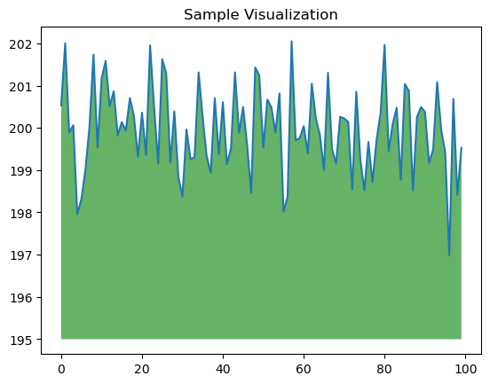

```python
import numpy as np
from matplotlib import pyplot as plt

ys = 200 + np.random.randn(100)
x = [x for x in range(len(ys))]

plt.plot(x, ys, '-')
plt.fill_between(x, ys, 195, where=(ys > 195), facecolor='g', alpha=0.6)

plt.title("Sample Visualization")
plt.show()
```

### Embed mathematical functions

Using MathJax you can embed mathematical functions both inline $e^{i\pi} + 1 = 0$ and displayed: \begin{equation} e^x=\sum_{i=0}^\infty \frac{1}{i!}x^i \end{equation}

This is very useful for research into advanced Machine Learning or AI when you need to capture different variations. You can document the maths for display and then have the code to run it.

### Use Google Colab means that your work is online, sharable and backed up

- [Google Colab](https://colab.google/)
- [Introduction to Google Colab Features](https://colab.research.google.com/notebooks/basic_features_overview.ipynb)
- These notebooks run *remotely* (ie, you don't access any data stored on your computer)
- You have access to different computing options like GPU and TPU systems
- You can share and collaborate on the notebooks and run from anywhere (your work is backed up)

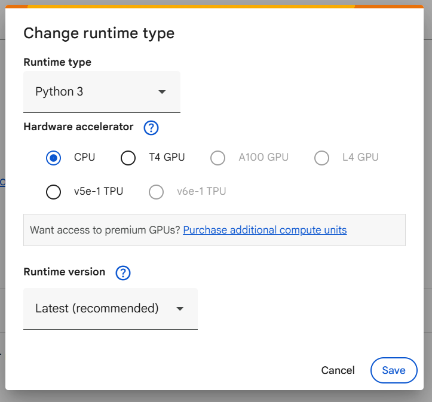

### Use git to store and share your notebooks and they will be rendered for display

Notebook files are text (JSON) so you can do version control (kind of) through git repositories.

GitHub and Gitlab will *render* the notebook file to show the text and code but you can't run the notebook. Great for sharing your work!

[figure not shown]

You can also link your Google Colab account to your GitHub account and publish directly from Colab.

### Use widgets to create interactive dashboards

ipywidgets [Reference](https://ipywidgets.readthedocs.io/en/latest/user_install.html)

```python
import ipywidgets as widgets

widgets.IntSlider()
```

```
IntSlider(value=0)
```

### Export notebooks as code, pdf, html and more

[figure not shown]

### Convert your notebook to display as a slideshow

Like this one!

1. Open or Create your notebook
2. In Jupyter `View --> Right Sidebar --> Show Notebook Tools`
3. Assign each cell a Slide Type (Slide, Sub-slide, Fragment)
4. Open `Anaconda Prompt` on Windows or use the terminal in Linux
5. Run `jupyter nbconvert --to slides Name-of-notebook.ipynb --post serve`
6. Your javascript based presentation will open in the browser

## Tips and Tricks

- Learn the shortcuts (e.g., Shift+Enter to run a cell)
- At the left of code cells is a number. This tells you the order in which the code cells were executed.
- When you re-open a notebook you need to run the cells from the start. It won't remember imports or variables between sessions.
- Make a copy of a Colab Notebook to your Google Drive account so you can edit and save it.

## References

- DataCamp: https://www.datacamp.com/tutorial/installing-jupyter-notebook
- [Jupyter Documentation](https://jupyter-notebook.readthedocs.io/en/stable/notebook.html)
- [Google Colab](https://colab.google/notebooks/) - examples of advanced usage

Now: [Try it!](https://github.com/suzannelittle/ca682i/blob/master/notebooks/2_1_6_Reading_and_formatting_data.ipynb)